# Федеральное государственное автономное образовательное учреждение высшего образования «Национальный исследовательский ядерный университет «МИФИ»

### **ОТЧËТ**

**по лабораторной работе №1 (вариант 25)**  
**по дисциплине:** «Статистика»

**Выполнил:** студент группы Б22-701  
**Тюменцева Арина Владиславовна**

**Проверил:** Смирнов Д. С.

Москва, 2024 г.

### Введение

Данная лабораторная работа посвящена применению теоретических знаний описательной статистики для анализа предпочтений респондентов в отношении различных брендов в сфере моды и парфюмерии, проведению статистических исследований на языке R в среде разработки RStudio. В качестве данных предоставлен датасет размером 100 строк на 30 столбцов, где строки представляют ответы респондентов (баллы), а столбцы — вопросы, заданные респондентам (оценка брендов по различным характеристикам). Объектами исследования являются четыре бренда: **Chanel**, **Tom Ford**, **Dior** и **Gucci**. Каждый бренд оценивается по ключевым параметрам, включающим: **комплиментарность**, **универсальность**, **стойкость**, **соответствие модным тенденциям** и **красота**.

### Проблема

Восприятие брендов — это личные предпочтения и ожидания потребителей. Оценка качества бренда не может опираться исключительно на объективные параметры. Чтобы выявить сильные и слабые стороны каждого бренда с точки зрения целевой аудитории, необходимо проанализировать мнения респондентов, систематизировать данные по ключевым параметрам и получить целостное представление о предпочтениях покупателей в рамках выбранных брендов.

### Цель работы

Цель данной работы — провести анализ предпочтений респондентов методами описательной статистики, оценить восприятие брендов методом идеальной точки и сформулировать рекомендации для улучшения продуктов брендов, с учетом предпочтений целевой аудитории.

### Задачи

1. Изучить данные и подготовить их для анализа.
2. Произвести расчеты методом идеальной точки для каждого из брендов.
3. Оценить статистические показатели для идеального бренда и реальных данных по альтернативам.
4. Визуализировать результаты расчетов и проанализировать графики.
5. Описать результаты исследования с точки зрения маркетинга и предложить направления для улучшения брендов.

#### **Ход работы:**

#### **Задание 1: загрузить материалы индивидуального проекта**

1. Загружаем данные для исследования предпочтений респондентов относительно брендов **Chanel**, **Tom Ford**, **Dior** и **Gucci**.
2. Просмотрим структуру загруженных данных

#### Подготовим данные для дальнейших вычислений

3. Создаём пустую матрицу `my_matrix` для хранения отклонений по каждому бренду и респонденту. В дальнейшем она будет заполняться значениями отклонений.

#### **Задание 2: расчёт отклонений альтернатив от идеальной точки для респондентов**

Для каждого бренда вычисляем отклонения от идеальной точки, что позволяет оценить восприятие бренда с точки зрения «идеального» продукта. Чем меньше значение, тем ближе бренд к идеалу. Суммарное отклонение каждого респондента по брендам используется для дальнейших расчетов показателей.

I(i) - идеальная точка

X(i) - убеждения

```r
load(file= "/Users/arinatyumentseva/Desktop/3 курс/Лабораторная работа №1/Вариант25_Б22-701_Тюменцева.RData")
str(Result)
```

```
## 'data.frame':    100 obs. of  30 variables:
##  $ Насколько, по вашему мнению, идеальные духи должны обладать комплиментарностью с другими ароматами и продуктами? (1 - совершенно не комплиментарные, 7 - идеально сочетаются с другими ароматами): int  6 6 4 6 7 4 3 3 4 4 ...
##  $ Насколько, по вашему мнению, идеальные духи должны быть универсальными? (1 - подходят только для определенных случаев, 7 - подходят для любых ситуаций и времени года)                           : int  2 2 3 2 3 3 2 2 2 3 ...
##  $ Насколько, по вашему мнению, идеальные духи должны обладать стойкостью? (1 - аромат исчезает через короткое время, 7 - аромат сохраняется на коже весь день)                                     : int  2 5 1 1 4 5 7 2 1 4 ...
##  $ Насколько, по вашему мнению, идеальные духи должны соответствовать модным тенденциям? (1 - вечная классика, 7 - всегда в тренде и соответствуют современным модным направлениям)                 : int  5 7 7 6 4 7 7 7 7 7 ...
##  $ Насколько, по вашему мнению, идеальные духи должны обладать красотой флакона? (1 - простой невыразительный флакон, 7 - флакон должен быть экстравагантным и причудливым)                         : int  5 4 4 2 4 5 6 6 5 4 ...
##  $ Насколько вам важна комплиментарность духов с другими ароматами и продуктами?                                                                                                                    : int  4 1 1 1 6 2 2 2 1 1 ...
##  $ Насколько вам важна универсальность духов?                                                                                                                                                       : int  4 3 4 7 6 4 6 4 4 3 ...
##  $ Насколько вам важна стойкость духов?                                                                                                                                                             : int  2 3 5 2 3 2 2 3 2 6 ...
##  $ Насколько вам важно, чтобы духи соответствовали модным тенденциям?                                                                                                                               : int  5 7 7 1 5 6 2 7 6 6 ...
##  $ Насколько вам важна красота флакона духов?                                                                                                                                                       : int  1 1 1 1 1 2 1 1 1 2 ...
##  $ "Насколько, по Вашему мнению, Chanel обладает комплиментарностью с другими ароматами и продуктами?"                                                                                              : int  4 7 4 4 4 4 2 4 3 1 ...
##  $ "Насколько, по Вашему мнению, Chanel имеет универсальность?"                                                                                                                                     : int  2 1 7 1 1 4 3 1 2 5 ...
##  $ "Насколько, по Вашему мнению, Chanel обладает стойкостью?"                                                                                                                                       : int  5 5 5 5 4 4 4 1 5 7 ...
##  $ "Насколько, по Вашему мнению, Chanel соответствует моде?"                                                                                                                                        : int  6 1 2 4 2 4 3 3 6 2 ...
```

[output cut: 16 more lines]

```r
brand_names <- c("Chanel", "Tom Ford", "Dior", "Gucci")
respondent_names <- row.names(Result)

my_matrix <- data.frame(matrix (nrow = length(respondent_names),
                                ncol = length(brand_names)))
colnames(my_matrix) <- brand_names
row.names(my_matrix) <- respondent_names

for (r in respondent_names) {
  # Chanel:
  my_matrix[r, 1] <- sum(Result[r, 6:10] * abs(Result[r, 1:5] - Result[r, 11:15]))

  # Tom Ford:
  my_matrix[r, 2] <- sum(Result[r, 6:10] * abs(Result[r, 1:5] - Result[r, 16:20]))

  # Dior:
  my_matrix[r, 3] <- sum(Result[r, 6:10] * abs(Result[r, 1:5] - Result[r, 21:25]))

  # Gucci:
  my_matrix[r, 4] <- sum(Result[r, 6:10] * abs(Result[r, 1:5] - Result[r, 26:30]))
}
```

#### **Задание 3: расчёт показателей центра распределений отклонений по каждой альтернативе**

1. Выполняем установку и подключение пакета `DescTools`, который содержит функции для дополнительных статистических расчетов. Этот пакет используется для вычисления показателей, таких как: **мода (Mode)**, **асимметрия (Skew)** и **эксцесс (Kurt)**, которые не входят в стандартные функции R. Подключение `DescTools` позволяет выполнять эти вычисления удобным образом и делает доступными расширенные статистические методы для анализа данных.

   ```r
   library(DescTools)
   ```

2. Создаём `Center_Estimates` для хранения статистик центра распределения (среднее, медиана, мода и усечённое среднее) по каждому бренду. Это поможет увидеть, какие бренды имеют наименьшие отклонения и более предпочтительны для респондентов.

   ```r
   center_estimates_names <- c("Среднее арифметическое", "Медиана", "Мода", "Усечённое среднее")

   Center_Estimates <- data.frame(matrix(nrow = length(center_estimates_names), ncol = length(brand_names)))
   colnames(Center_Estimates) <- brand_names
   row.names(Center_Estimates) <- center_estimates_names
   ```

3. Рассчитываем средние значения для каждого бренда. **Среднее арифметическое** показывает общую среднюю оценку бренда, **медиана** — центральное значение, **мода** — наиболее часто встречающееся значение, и **усечённое среднее** помогает учитывать отклонения без влияния выбросов.

```r
for (b in brand_names) {
  D <- my_matrix[,b]

  Center_Estimates[1,b] <- mean(D)

  Center_Estimates[2,b] <- median(D)

  modes <- Mode(D)
  med <- median(D)
  Center_Estimates[3, b] <- modes[which.min(abs(modes - med))]

  Center_Estimates[4,b] <- mean(D, trim = 0.05, na.rm=TRUE)
}

print(Center_Estimates)
```

```
##                          Chanel Tom Ford     Dior    Gucci
## Среднее арифметическое 38.38000    42.99 44.43000 36.46000
## Медиана                36.00000    42.00 45.50000 36.00000
## Мода                   33.00000    44.00 47.00000 36.00000
## Усечённое среднее      37.84444    42.30 44.01111 36.12222
```

#### **Задание 4: оценить показатели вариации и размаха баллов по альтернативам**

Создаем `Variation_Estimates` для хранения **коэффициентов дисперсии, стандартного отклонения, вариации** и **размаха** для каждого бренда. Это помогает оценить стабильность восприятия брендов респондентами.

```r
variation_estimates_names <- c("Дисперсия", "Ст. отклонение", "Коэфф. вариации",
                               "Размах вариации")

Variation_Estimates <- data.frame(matrix(nrow = length(variation_estimates_names),
                                         ncol = length(brand_names)))
colnames(Variation_Estimates) <- brand_names
row.names(Variation_Estimates) <- variation_estimates_names
```

Рассчитываем показатели вариации: **дисперсия** и **стандартное отклонение** показывают, насколько значения в наборе данных отклоняются от их среднего значения, **коэффициент вариации** нормализует разброс, чтобы можно было сравнивать бренды, а **размах** показывает диапазон отклонений; это разница между максимальным и минимальным значением в наборе данных. Он является самой простой и наименее точной мерой вариации. Чем меньше разброс, тем стабильнее бренд воспринимается респондентами.

```r
for (b in brand_names) {
  D <- my_matrix[, b]

  var_value <- var(D, na.rm = TRUE)
  Variation_Estimates[1, b] <- var_value

  sd_value <- sd(D, na.rm = TRUE)
  Variation_Estimates[2, b] <- sd_value

  mean_value <- mean(D, na.rm = TRUE)
  Variation_Estimates[3, b] <- (sd_value / abs(mean_value)) * 100

  Variation_Estimates[4, b] <- max(D, na.rm = TRUE) - min(D, na.rm = TRUE)
}

print("Показатели вариации и размаха:")
```

```
## [1] "Показатели вариации и размаха:"
```

```r
print(Variation_Estimates)
```

```
##                    Chanel  Tom Ford      Dior     Gucci
## Дисперсия       229.91475 260.99990 320.61121 206.00848
## Ст. отклонение   15.16294  16.15549  17.90562  14.35300
## Коэфф. вариации  39.50740  37.57965  40.30074  39.36642
## Размах вариации  73.00000  74.00000  72.00000  80.00000
```

- **Дисперсия и стандартное отклонение** показывают, насколько оценки отклоняются от среднего значения. Чем выше эти значения, тем больше различий в мнениях. У брендов **Dior** (дисперсия 320.61, стандартное отклонение 17.91) и **Tom Ford** (дисперсия 260.99, стандартное отклонение 16.16) самые высокие показатели, что указывает на значительную изменчивость восприятий этих брендов. Это может говорить о полярных мнениях среди респондентов — некоторым респондентам бренд явно нравится, в то время как у других он вызывает менее положительное восприятие.
- **Коэффициент вариации** нормализует разброс оценок, позволяя сравнивать изменчивость между брендами. Самые высокие коэффициенты у **Dior** (40.3) и **Chanel** (39.51), что говорит о большей вариативности восприятия этих брендов по сравнению с другими. Такое высокое значение коэффициента может свидетельствовать о неоднородности целевой аудитории или о противоречивых ассоциациях, связанных с брендом.
- **Размах** (разница между максимальным и минимальным значениями) отражает диапазон оценок и является простой мерой изменчивости. Чем меньше размах, тем стабильнее воспринимается бренд. Наименьший разброс наблюдается у **Dior**, что указывает на более однозначное и согласованное восприятие этого бренда респондентами.

**Задание 5: оценить показатели характера распределения(ассиметрии, эксцесса, дифференциации) для каждой альтернативы**

`Distribution_Estimates` содержит статистики для оценки характера распределений: **асимметрия, эксцесс, квартильные значения, коэффициент дифференциации** и **IQR**. Это позволяет увидеть, есть ли перекос в оценках.

```r
distribution_estimates_names <- c("Коэффициент асимметрии", "Коэффициент эксцесса",
                                  "Нижняя квартиль", "Верхняя квартиль",
                                  "Медиана", "Коэффициент дифференциации",
                                  "Интерквартильный размах (IQR)")

Distribution_Estimates <- data.frame(matrix(nrow = length(distribution_estimates_names),
                                            ncol = length(brand_names)))
colnames(Distribution_Estimates) <- brand_names
row.names(Distribution_Estimates) <- distribution_estimates_names
```

Мы видим, как распределение оценок каждого бренда отклоняется от симметрии (**асимметрия**) и нормального распределения (**эксцесс**). **Коэффициент дифференциации** позволяет оценить стабильность распределения относительно медианы.

```r
for (b in brand_names) {
  D <- my_matrix[, b]
  n <- length(D)
  m <- mean(D)
  s <- sd(D)

   skew <- sum((D - m)^3 /s^3)/n
  Distribution_Estimates[1, b] <- skew

  kurt <- sum((D - m)^4/s^4)/n - 3
  Distribution_Estimates[2, b] <- kurt

  quantiles <- quantile(D, probs = c(0.25, 0.5, 0.75), na.rm = TRUE)

  Distribution_Estimates[3, b] <- quantiles[1]

  Distribution_Estimates[4, b] <- quantiles[3]

  Distribution_Estimates[5, b] <- quantiles[2]

  diff_coeff <- quantiles[3]/quantiles[1]
  Distribution_Estimates[6, b] <- diff_coeff

  Distribution_Estimates[7, b] <- quantiles[3] - quantiles[1]

}

print("Показатели асимметрии, эксцесса и дифференциации:")
```

```
## [1] "Показатели асимметрии, эксцесса и дифференциации:"
```

```r
print(Distribution_Estimates)
```

```
##                                   Chanel    Tom Ford       Dior      Gucci
## Коэффициент асимметрии         0.5439769  0.49175894  0.2593424  0.4071828
## Коэффициент эксцесса          -0.1664321 -0.09464321 -0.7362215  0.5805079
## Нижняя квартиль               27.0000000 30.00000000 31.0000000 26.0000000
## Верхняя квартиль              47.2500000 53.25000000 55.2500000 45.0000000
## Медиана                       36.0000000 42.00000000 45.5000000 36.0000000
## Коэффициент дифференциации     1.7500000  1.77500000  1.7822581  1.7307692
## Интерквартильный размах (IQR) 20.2500000 23.25000000 24.2500000 19.0000000
```

#### Chanel

- **Коэффициент асимметрии**: Положительный (0.54) указывает на правостороннюю асимметрию, что значит, что оценки смещены в сторону высоких значений. Это может указывать на положительное восприятие бренда, хотя некоторые респонденты оценивают его чуть ниже.
- **Коэффициент эксцесса**: Небольшое отрицательное значение (-0.17) говорит о плосковершинном распределении, что означает более равномерное распределение оценок и отсутствие концентрации вокруг среднего.
- **Коэффициент дифференциации**: 1.75, что говорит о некотором различии во мнениях респондентов, но относительно стабильном восприятии бренда.

#### Tom Ford

- **Коэффициент асимметрии**: 0.49, правосторонняя асимметрия, указывающая на несколько высокие оценки, возможно, из-за восприятия бренда как более люксового.
- **Коэффициент эксцесса**: -0.095 — почти нулевое значение, указывающее на близость распределения к нормальному. Оценки равномерно распределены без ярко выраженных крайних мнений.
- **Коэффициент дифференциации**: 1.775 — относительно высокое значение, что говорит о нескольких различных мнениях респондентов относительно бренда.

#### Dior

- **Коэффициент асимметрии**: 0.26, что указывает на почти симметричное распределение с легким смещением в сторону высоких значений, что может говорить о положительном восприятии бренда.
- **Коэффициент эксцесса**: -0.74, что указывает на плосковершинное распределение — мнения респондентов достаточно разнообразны и распределены вокруг среднего.
- **Коэффициент дифференциации**: 1.782, самое высокое значение, что показывает широкое различие во мнениях и указывает на то, что Dior вызывает наибольшую неоднозначность в оценках.

#### Gucci

- **Коэффициент асимметрии**: 0.41 — положительное значение, указывающее на несколько высоких оценок. Респонденты склонны оценивать бренд высоко, хотя некоторые ставят более низкие оценки.
- **Коэффициент эксцесса**: 0.581 — положительный эксцесс указывает на более заостренное распределение, с большей концентрацией около среднего, что может означать сбалансированное восприятие бренда.
- **Коэффициент дифференциации**: 1.73 — самое низкое значение, что говорит о наиболее равномерном восприятии и меньшем разбросе оценок по сравнению с остальными брендами.

  Для оценки характера распределений использовались такие показатели, как коэффициенты асимметрии и эксцесса: **Коэффициент асимметрии** положителен у всех брендов, но наиболее высокие значения наблюдаются у **Chanel** (0.54) и **Tom Ford** (0.49), что указывает на смещение восприятия в сторону более высоких оценок. **Коэффициент эксцесса** у **Gucci** (0.581) показывает более «острые» пики распределения, что свидетельствует о высокой концентрации оценок вокруг одного значения, в отличие от более равномерного распределения у **Dior**.

  Среди всех альтернатив, наибольший коэффициент дифференциации, то есть, отношение верхней квартили к нижней, показывает Dior, а наименьший Gucci.

#### **Задание 6: оценить средние характеристики и разброс значений в восприятии респондентами идеального исполнения исследуемого продукта**

Мы проводим оценку идеальных характеристик с точки зрения респондентов, чтобы сравнить восприятие респондентов с фактическими показателями брендов.

Поэтому, мы используем исходную таблицу `Result` , в которой содержатся атрибуты, представляющие **идеальные ожидания респондентов** по каждому критерию, такие как **комплиментарность, универсальность, стойкость**, **соответствие модным тенденциям** и **красота**, а также весовые коэффициенты, которые отражают важность этих атрибутов для идеального продукта.

Создаем таблицу `table_atribute` для хранения статистических характеристик атрибутов (комплиментарность, универсальность и др.). Эти данные помогают понять, какие атрибуты для респондентов наиболее важны и как они оценивают идеальное соответствие продукта.

Здесь рассчитываем параметры для каждого атрибута идеального продукта:

```r
central_estimates <- c("Среднее арифметическое", "Медиана", "Мода", "Усечённое среднее",
         "Дисперсия", "Стандартное отклонение", "Коэффициент вариации")
atribute_names <- c("Комплиментарность", "Универсальность", "Стойкость",
         "Соответствие модным тенденциям", "Красота")
table_atribute <- data.frame(matrix(ncol = length(atribute_names),
                                    nrow = length(central_estimates)))
names(table_atribute) <- atribute_names
row.names(table_atribute) <- central_estimates
for (i in 1:5) {
  table_atribute [1,i] <- mean(as.numeric(as.character(Result[1:100, i])))
  table_atribute [2,i] <- median(as.numeric(as.character(Result[1:100, i])))
  table_atribute [3,i] <- Mode(as.numeric(as.character(Result[1:100, i])))
  table_atribute [4,i] <- mean(as.numeric(as.character(Result[1:100, i])), trim = 0.05, na.rm = TRUE)
  table_atribute [5,i] <- var(as.numeric(as.character(Result[1:100, i])))
  table_atribute [6,i] <- sd(as.numeric(as.character(Result[1:100, i])))
  table_atribute [7,i] <- table_atribute [6,i] / abs(table_atribute[1,i]) * 100
}
print(table_atribute)
```

```
##                        Комплиментарность Универсальность Стойкость
## Среднее арифметическое          4.200000        2.750000  2.500000
## Медиана                         4.000000        2.000000  2.000000
## Мода                            4.000000        2.000000  1.000000
## Усечённое среднее               4.222222        2.611111  2.333333
## Дисперсия                       2.606061        2.431818  3.949495
## Стандартное отклонение          1.614330        1.559429  1.987334
## Коэффициент вариации           38.436423       56.706502 79.493345
##                        Соответствие модным тенденциям   Красота
## Среднее арифметическое                       5.660000  4.740000
## Медиана                                      6.000000  5.000000
## Мода                                         7.000000  5.000000
## Усечённое среднее                            5.811111  4.822222
## Дисперсия                                    2.933737  2.254949
## Стандартное отклонение                       1.712816  1.501649
## Коэффициент вариации                        30.261760 31.680357
```

**Красота**:

- Высокое среднее значение (4.74), медиана (5) и мода (5) показывают, что красота также важна для большинства респондентов.
- Коэффициент вариации (31.68) подтверждает, что оценки респондентов относительно стабильны, что усиливает вывод о высокой значимости этого критерия.

**Комплиментарность**:

- Среднее значение (4.2) и медиана (4) указывают на важность атрибута, хотя и несколько ниже, чем у первых двух.
- Более высокий коэффициент вариации (38.44) говорит о том, что восприятие этого атрибута менее стабильное, и мнения респондентов могут различаться.

**Универсальность** и **Стойкость**:

- Эти атрибуты имеют более низкие средние оценки (2.75 для универсальности и 2.5 для стойкости), что предполагает, что они менее значимы для респондентов.
- Высокий коэффициент вариации, у универсальности (56.71), особенно у стойкости (79.49), указывает на сильную изменчивость восприятия, что может свидетельствовать о противоречивом отношении к этим характеристикам среди респондентов.

Для достижения соответствия ожиданиям можно усилить внимание к **стойкости** и **универсальности**, если это соответствует стратегии бренда, чтобы создать более цельный и предпочтительный образ продукта.

### Задание 7: представление средних характеристик идеального исполнения продукта в виде паутинчатой и столбчатой диаграмм

Для представления результатов строим несколько графиков.

Строим паутинчатую диаграмму:

```r
if (!requireNamespace("fmsb", quietly = TRUE)) {
  install.packages("fmsb")
}
library(fmsb)
```

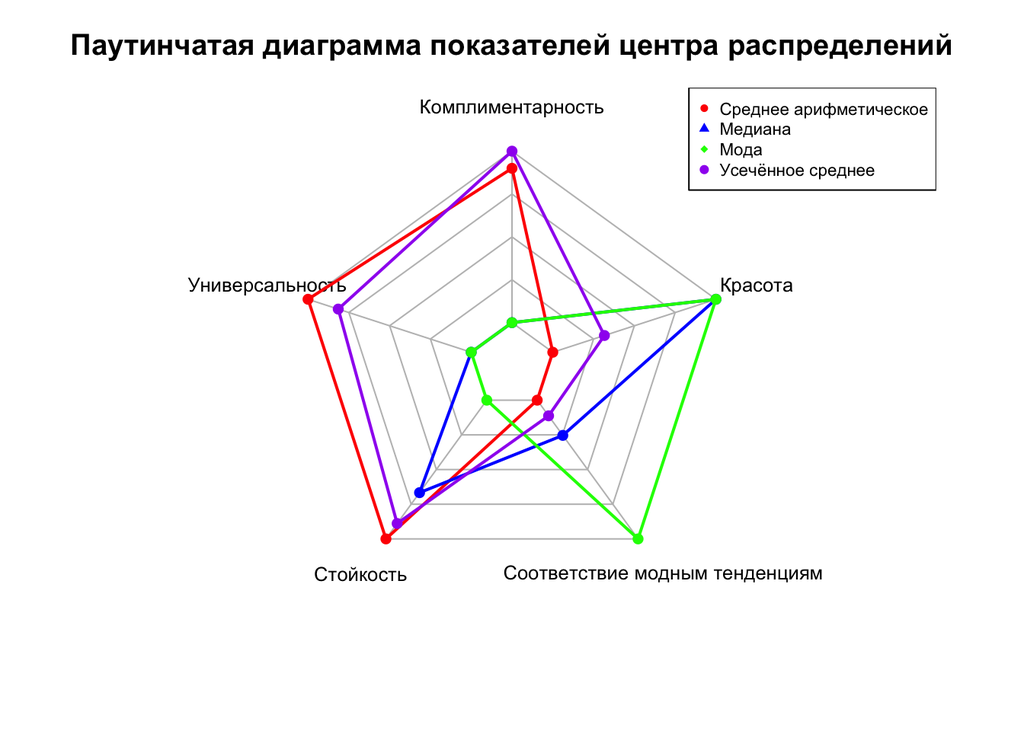

```r
max_values <- apply(table_atribute[1:4, ], 2, max, na.rm = TRUE)
min_values <- apply(table_atribute[1:4, ], 2, min, na.rm = TRUE)

radar_data <- rbind(max_values, min_values, table_atribute[1:4, ])

colors <- c("red", "blue", "green", "purple")

par(mar = c(3, 3, 3, 3))

radarchart(radar_data,
           cglty = 1,
           cglcol = "gray",
           pcol = colors,
           plwd = 2,
           plty = 1,
           vlcex = 0.8)
title(main = "Паутинчатая диаграмма показателей центра распределений")

legend("topright",
       legend = row.names(radar_data)[-c(1, 2)],
       pch = 16:(15 + length(row.names(radar_data)[-c(1, 2)])),
       col = colors,
       cex = 0.7)
```

Строим столбчатую диаграмму:

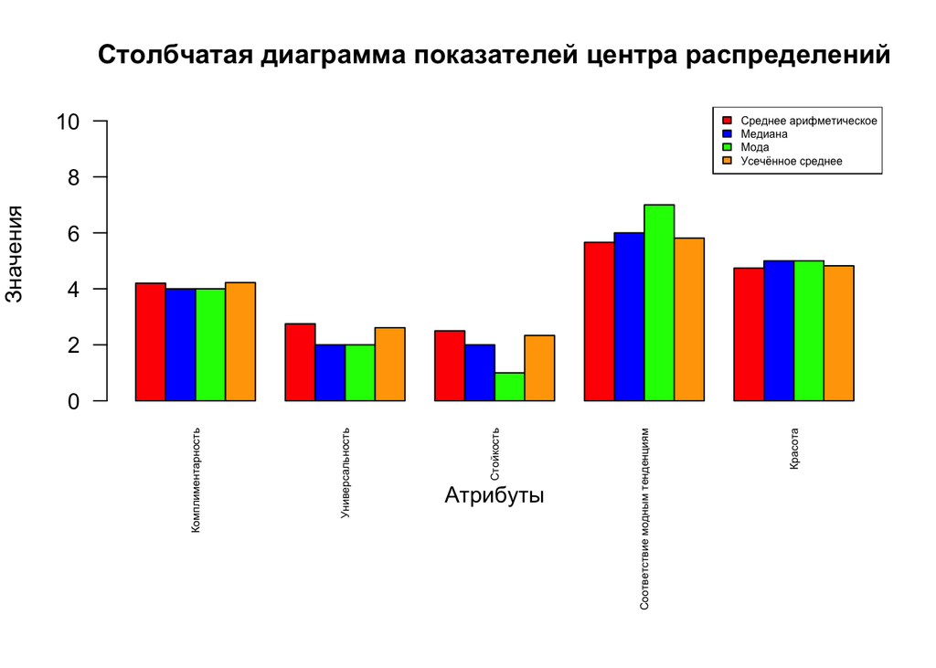

```r
colors <- rainbow(ncol(table_atribute))


max_values <- as.data.frame(t(apply(table_atribute[1:4, ], 2, max, na.rm = TRUE)))
min_values <- as.data.frame(t(apply(table_atribute[1:4, ], 2, min, na.rm = TRUE)))

rownames(max_values) <- "Max"
rownames(min_values) <- "Min"


bar_data <- as.matrix(table_atribute[1:4, ])

par(mar = c(10, 4, 4, 2))

colors <- c("red", "blue", "green", "orange")


barplot(bar_data,
        beside = TRUE,
        col = colors,
        main = "Столбчатая диаграмма показателей центра распределений",
        xlab = "Атрибуты",
        ylab = "Значения",
        ylim = c(0, max(bar_data, na.rm = TRUE) * 1.5),
        cex.names = 0.5,
        las = 2)


legend("topright",
       legend = row.names(table_atribute)[1:4],
       fill = colors,
       cex = 0.5)
```

### Задание 8: представление баллов альтернатив в виде упорядоченного по убыванию линейного графика

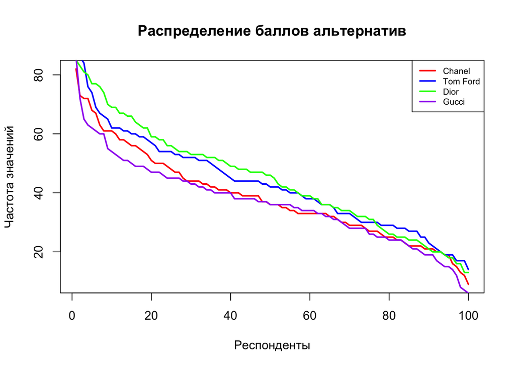

```r
plot(x = my_matrix$Chanel[order(my_matrix$Chanel, decreasing=TRUE)], type = "l",
     main = "Распределение баллов альтернатив", ylab = "Частота значений", xlab = "Респонденты",
     lwd = 2, col = "red")

points(x = my_matrix$`Tom Ford`[order(my_matrix$`Tom Ford`, decreasing=TRUE)],
       type = "l", lwd = 2, col = "blue")

points(x = my_matrix$Dior[order(my_matrix$Dior, decreasing=TRUE)],
       type = "l", lwd = 2, col = "green")

points(x = my_matrix$Gucci[order(my_matrix$Gucci, decreasing=TRUE)],
       type = "l", lwd = 2, col = "purple")

legend("topright",
       legend = colnames(my_matrix),
       col = c("red", "blue", "green", "purple"),
       lty = 1,
       lwd = 2,
       cex = 0.7)
```

#### **Задание 9: представьте распределение баллов по каждой альтернативе в виде диаграммы размаха**

Диаграмма размаха (boxplot) используется для визуализации **медианы, интерквартильного размаха** и **выбросов**. Она помогает оценить устойчивость оценок брендов.

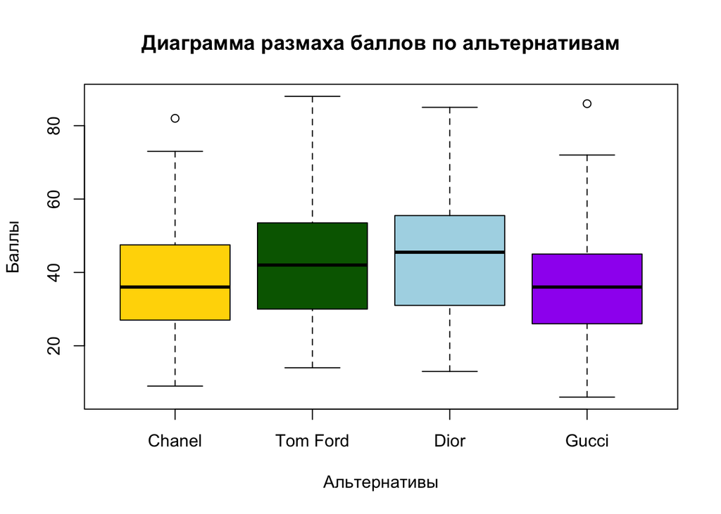

```r
boxplot(my_matrix,
        main = "Диаграмма размаха баллов по альтернативам",
        ylab = "Баллы",
        xlab = "Альтернативы",
        col = c("gold", "darkgreen", "lightblue", "purple")
)
```

### **Выводы:**

Для укрепления позиции Dior рекомендуется провести коммуникационные кампании, акцентирующие его ключевые положительные качества и согласованные представления покупателей о бренде.

#### **Список литературы:**

1. “Описательная статистика” [презентация] Смирнов Д.С., к.э.н
2. The R Graph Gallery “Basic radar chart” [Электронный ресурс].

```
URL: https://r-graph-gallery.com/142-basic-radar-chart.html
```

3. Роберт И. Кабаков

   R в действии. Анализ и визуализация данных в программе R / пер. с англ. Полины А. Волковой. – М.: ДМК Пресс, 2014. – 588 с.: ил.